# Modeling and Optimization

Network Optimization

Sebastian Souyris

MGMT 6460 Fall 2026

## Roadmap

1. **Part I. Paths and Trees**
   - Network Problems: Paths, Trees and Flows
   - Network Vocabulary
   - The Shortest Path Algorithm
   - Minimum Spanning Tree: The Greedy Rule
   - Practice: Shortest Paths and Spanning Trees
2. **Part II. Flows**
   - Maximum Flow: Augmenting Paths and Cuts
   - Minimum Cost Flow and Its Special Cases
   - A Minimum Cost Flow Model: Distribution Unlimited
   - Project Scheduling as an LP (Optional)
   - Practice: Minimum Cost Flow Formulations
3. Conclusions
4. Appendix: References and a Voluntary Problem

# Network Problems: Paths, Trees and Flows

## Feeding 100 Million People a Year

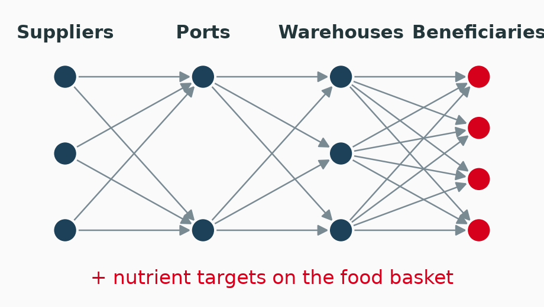

- The UN World Food Programme (WFP) assists about **100 million people** in more than 80 countries a year (Peters et al., 2022)
- Its tool **Optimus** plans the food basket and its route together

**The result**

Iraq: 12% lower cost at the same nutrition (Peters et al., 2021). WFP’s planning tools saved more than USD 150 million (Peters et al., 2022).

## A Delivery Network: Three Questions

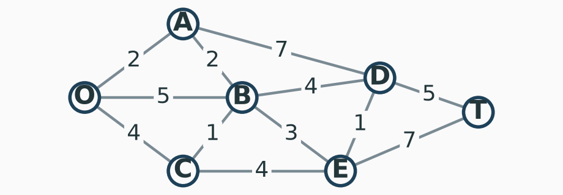

| Question | Network problem |
| --- | --- |
| Shortest truck route from warehouse O to customer T? | Shortest path |
| Fiber links joining all seven sites, at least total length? | Minimum spanning tree |
| Most truckloads per day from O to T, with a limit per road? | Maximum flow |

# Network Vocabulary

## Nodes, Links and Paths

| Term | Meaning |
| --- | --- |
| Node | A point: a site |
| Link | Joins two nodes, either way: a road |
| Arc | A link with a direction, ${A \to B}$ |
| Path | Distinct links joining two nodes |
| Cycle | A path back to its start |

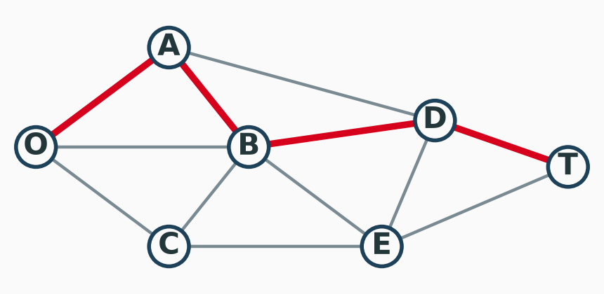

The path O–A–B–D–T in red. O–A–B–O is a cycle.

## Trees

- **Connected network:** a path joins every pair of nodes
- **Tree:** connected, with no cycle
- **Spanning tree:** a tree that reaches every node. With ${n}$ nodes it has ${n - 1}$ links

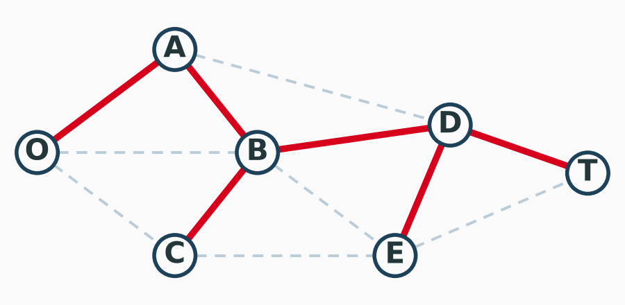

A spanning tree: 7 nodes, 6 links.

## Supply, Demand and Capacity

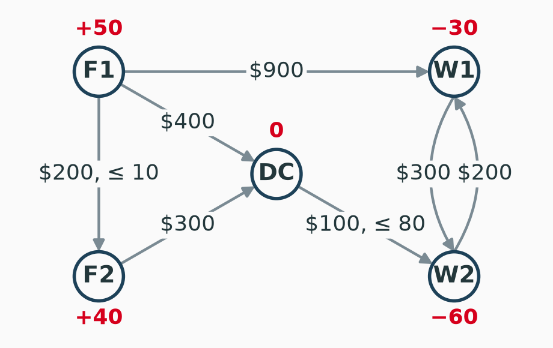

| Node | Flow | Here |
| --- | --- | --- |
| Supply | Out > in | F1, F2 |
| Demand | In > out | W1, W2 |
| Transshipment | In = out | DC |

- **DC:** the distribution center
- **Capacity:** the most an arc carries
- **Cost:** per unit of flow on an arc

# The Shortest Path Algorithm

## The Problem

**Shortest path**

In a connected network with a nonnegative length on each link, find the path of least total length from an **origin** to a **destination**.

- Lengths can be miles, dollars or hours
- **Idea.** Find the nodes in order of their distance from the origin: the nearest, the second nearest, and so on, until the destination
- A node whose shortest distance is known is solved

## The Shortest Path Algorithm

Iteration ${n}$ finds the ${n}$th nearest node to the origin.

1. Each solved node proposes its closest unsolved neighbor
2. **Total distance:** the solved node’s distance plus that link
3. The smallest total is the ${n}$th nearest node: record its distance and its last connection
4. Stop at the destination; read the path back through the last connections

**Ties**

Equal totals are solved together. Two last connections into a node mean two shortest paths.

## Shortest Path on the Delivery Network

| *n* | Solved node | Closest unsolved | Total distance | *n*th nearest | Min. distance | Last connection |
| --- | --- | --- | --- | --- | --- | --- |
| 1 | O | A | 2 | A | 2 | OA |
| 2, 3 | A | B | 2 + 2 = 4 | B | 4 | AB |
|  | O | C | 4 | C | 4 | OC |
| 4 | A | D | 2 + 7 = 9 |  |  |  |
|  | B | E | 4 + 3 = 7 | E | 7 | BE |
|  | C | E | 4 + 4 = 8 |  |  |  |
| 5 | A | D | 2 + 7 = 9 |  |  |  |
|  | B | D | 4 + 4 = 8 | D | 8 | BD |
|  | E | D | 7 + 1 = 8 | D | 8 | ED |
| 6 | D | T | 8 + 5 = 13 | T | 13 | DT |
|  | E | T | 7 + 7 = 14 |  |  |  |

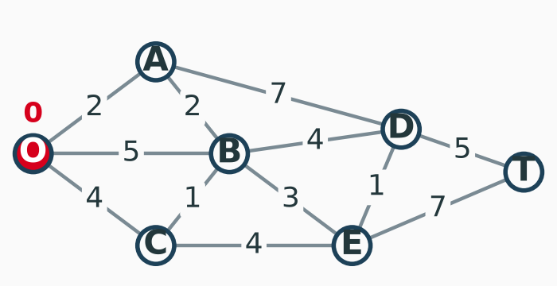

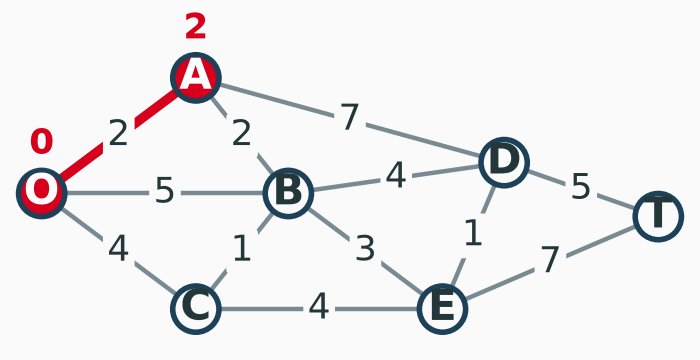

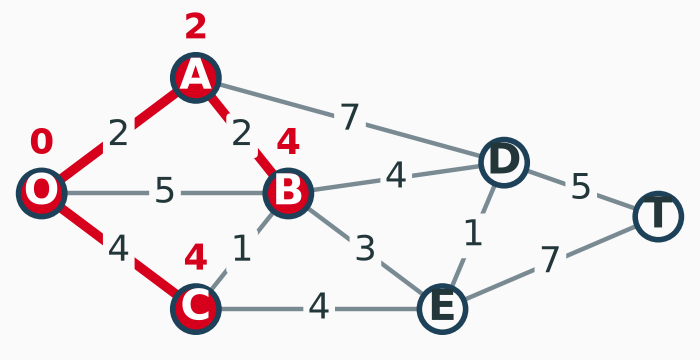

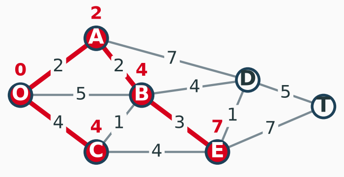

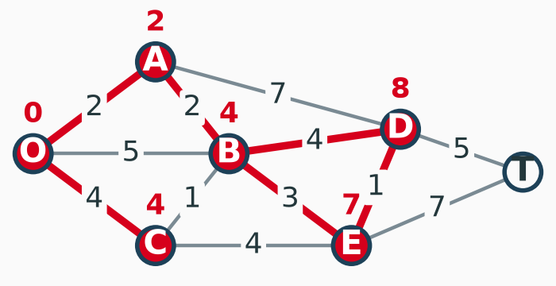

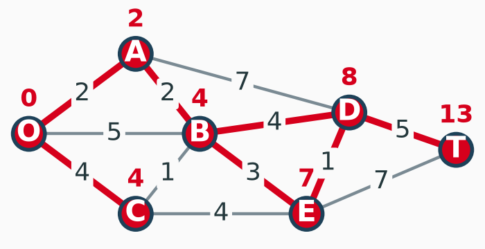

## Reading the Path Back

- From T, follow the last connections: T ← D, and D has two, BD and ED
- Through B: T ← D ← B ← A ← O
- Through E: T ← D ← E ← B ← A ← O

**Two shortest paths, 13 miles each**

O–A–B–D–T: ${2 + 2 + 4 + 5 = 13}$  
O–A–B–E–D–T: ${2 + 2 + 3 + 1 + 5 = 13}$

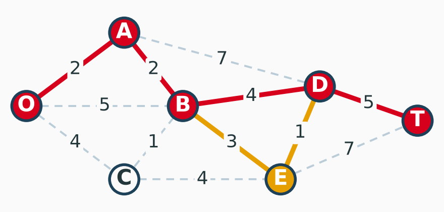

## The Shortest Path as an LP

Send **one unit** from O to T; each link is two arcs.

$$\begin{alignat*}{3}
\min~ & \rlap{\textstyle\sum_{(i,j)} c_{ij}\,x_{ij}} \\[4pt]
\text{s.t.}~ & \textstyle\sum_j x_{Oj} - \sum_j x_{jO} & \quad & {}= 1 \\
& \textstyle\sum_j x_{ij} - \sum_j x_{ji} & \quad & {}= 0 && \qquad i = A, \dots, E \\
& \textstyle\sum_j x_{Tj} - \sum_j x_{jT} & \quad & {}= -1 \\
& x_{ij} & \quad & {}\ge 0 && \qquad \text{every arc}
\end{alignat*}$$

- Out minus in: 1 at the origin, −1 at the destination, 0 elsewhere
- gurobipy: **13**, with ${x = 1}$ on O→A, A→B, B→D, D→T

**A preview of Part II**

No constraint says ${x_{ij} \in \{0, 1\}}$, yet the solver returns 0s and 1s: this is a minimum cost flow.

## Three Kinds of Applications

| Minimize the total | Example |
| --- | --- |
| Distance traveled | A delivery route |
| Cost of a sequence of activities | Replacing a machine: arc ${i \to j}$ buys in year ${i}$, sells in year ${j}$ |
| Time of a sequence of activities | A flight route under the day’s winds |

**Nonnegative lengths**

The shortest path algorithm needs every length ${\ge 0}$. The LP needs only that no cycle has negative length.

# Minimum Spanning Tree: The Greedy Rule

## Connecting Every Site

**Minimum spanning tree**

Given the nodes and the length of each possible link, choose links so that a path joins **every pair** of nodes, at the least total length.

- The answer is a spanning tree: a cycle would hold a link that can go
- The delivery network: fiber along the roads to all 7 sites

**The greedy rule (Prim, 1957)**

Start at any node. Add the **shortest link** joining a connected node to an unconnected one; repeat until all are connected. Break ties either way.

## The Greedy Rule on the Delivery Network

| Step | Connected | Links out, shortest first | Added | Length |
| --- | --- | --- | --- | --- |
| 1 | O | OA 2, OC 4, OB 5 | OA | 2 |
| 2 | OA | AB 2, OC 4, OB 5, … | AB | 2 |
| 3 | OAB | BC 1, BE 3, BD 4, … | BC | 1 |
| 4 | OABC | BE 3, BD 4, CE 4, … | BE | 3 |
| 5 | OABCE | DE 1, BD 4, AD 7, … | DE | 1 |
| 6 | OABCED | DT 5, ET 7 | DT | 5 |
|  | Total | 2 + 2 + 1 + 3 + 1 + 5 |  | **14** |

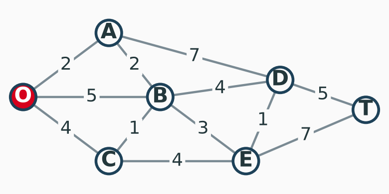

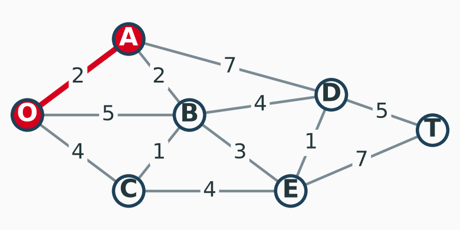

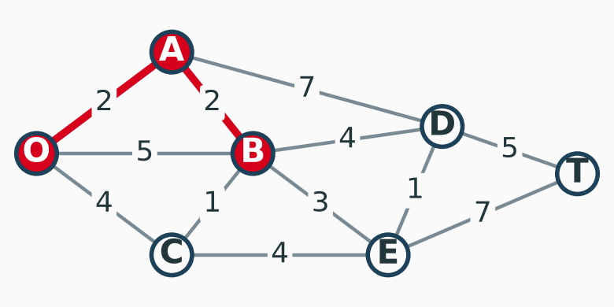

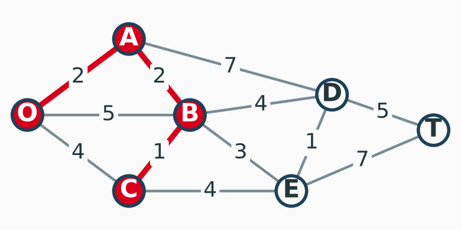

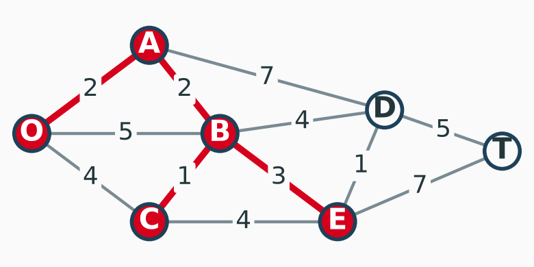

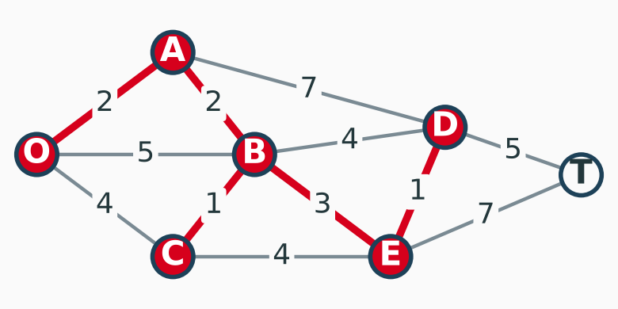

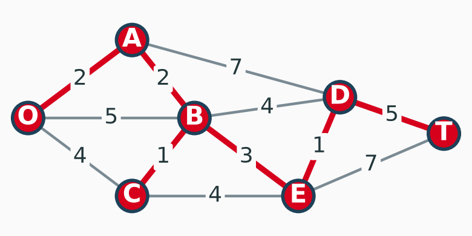

## Why Greedy Works for the Spanning Tree

**Spanning tree: greedy is optimal**

- Greedy adds the shortest link from a connected to an unconnected node
- Take an optimal tree with the links chosen so far. If it skips the new link, adding it closes a cycle
- The cycle crosses between the groups on a second link, at least as long as the new one
- Swap the two links: still a spanning tree, and its total length does not increase
- Repeat at every step: the greedy tree is optimal

## Why Greedy Fails for the Shortest Path

**Shortest path: greedy fails**

Drive to the nearest new site each time: O–A–B–C–E–D–T, ${2 + 2 + 1 + 4 + 1 + 5 = 15}$ miles. The shortest path is 13.

- The tree’s path from O to C is ${2 + 2 + 1 = 5}$; the road O–C is 4. A minimum spanning tree does not hold the shortest paths

## Where Spanning Trees Appear

- **Network design** at least cost: fiber-optic networks, power grids, pipelines, lightly used roads
- **Wiring** in electrical equipment and data centers
- **Clustering.** Build the minimum spanning tree on the distances between data points and delete its ${k - 1}$ longest links: ${k}$ clusters. This is single-linkage clustering

**Two classic greedy rules**

Prim (1957) grows one tree from a node. Kruskal (1956) adds the shortest remaining link anywhere, skipping links that close a cycle. Both find a minimum spanning tree.

# Practice: Shortest Paths and Spanning Trees

## Practice: The 2025 Exam 2 Network

**Practice Problem**

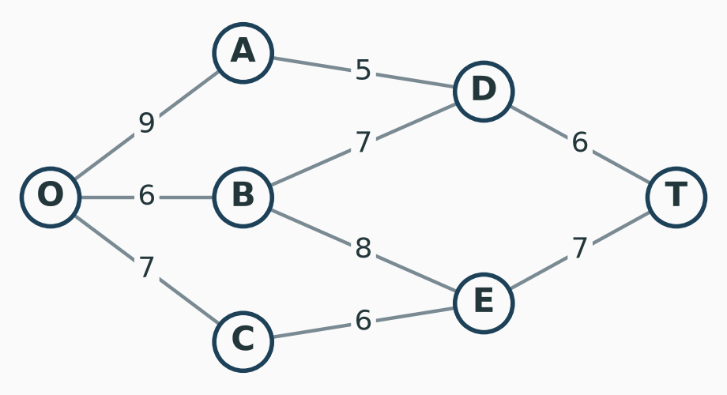

Each number is the distance between the two nodes the link joins.

**(a)** Find the shortest path from O to T with the shortest path algorithm. Show the table, one iteration at a time.

**(b)** Find a minimum spanning tree. Is it unique?

## Practice: Speedy Airlines

**Practice Problem**

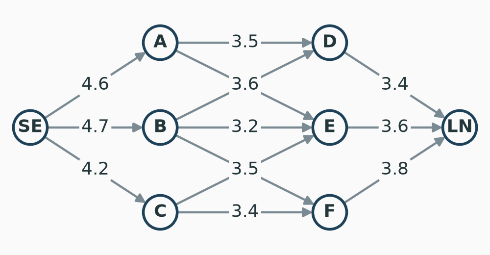

A flight leaves Seattle (SE) for London (LN). The winds set the flying time on each arc, in hours, and fuel follows time.

Find the route with the least total flying time with the shortest path algorithm.

## Part II: Flows

How much can a network carry, and at what cost?

# Maximum Flow: Augmenting Paths and Cuts

## The Delivery Network in Peak Season

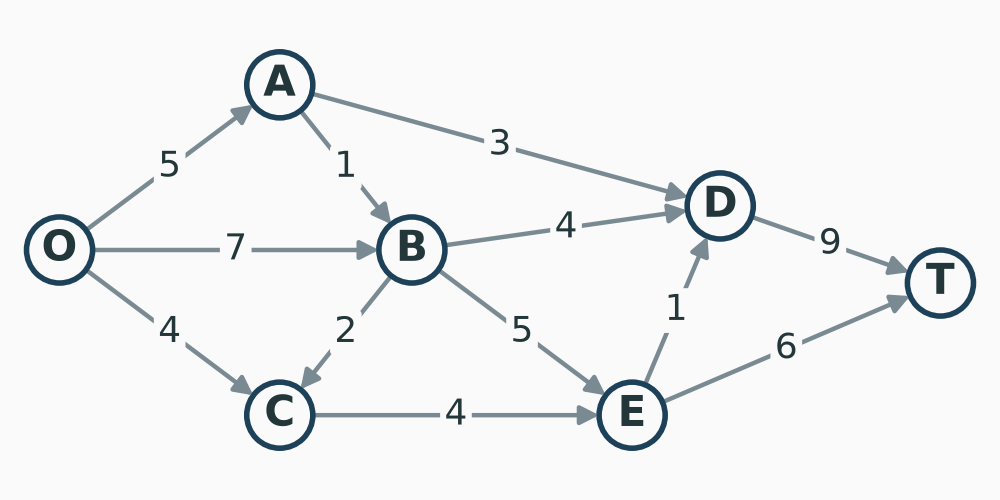

- Each road allows a limited number of truckloads per day, in the direction of its arrow
- How many truckloads per day can travel from O to T?

**A first try.** 5 truckloads O→B→E→T, 1 O→B→C→E→T, 1 O→B→C→E→D→T: 7 truckloads. They fill E→T and E→D, so no route that starts O→C can reach T.

## The Maximum Flow Problem

**Maximum flow**

All flow starts at the source and ends at the sink; every other node is a transshipment node; flow on an arc is at most its capacity. Maximize the flow from source to sink.

- Goods through a distribution network, from factories to customers
- Data through a computer network, gas through pipelines
- Vehicles through a road network

## Residual Capacity and Augmenting Paths

- Residual capacity of ${i \to j}$: capacity minus flow. A flow on ${i \to j}$ also gives ${j \to i}$ residual capacity: sending it back cancels it
- Augmenting path: source to sink, every arc with positive residual capacity

**Augmenting paths (Ford and Fulkerson, 1956)**

1. Find an augmenting path. If there is none, the flow is optimal
2. ${c^*}$ = the smallest residual capacity on the path
3. Send ${c^*}$ along it: subtract ${c^*}$ from each arc’s residual capacity, add ${c^*}$ to each reverse arc’s. Return to step 1

## Augmenting Paths on the Delivery Network

| Iteration | Augmenting path | Residual capacities | *c** | Total flow |
| --- | --- | --- | --- | --- |
| 1 | O→B→E→T | min{7, 5, 6} | 5 | 5 |
| 2 | O→A→D→T | min{5, 3, 9} | 3 | 8 |
| 3 | O→A→B→D→T | min{2, 1, 4, 6} | 1 | 9 |
| 4 | O→B→D→T | min{2, 3, 5} | 2 | 11 |
| 5 | O→C→E→D→T | min{4, 4, 1, 3} | 1 | 12 |
| 6 | O→C→E→T | min{3, 3, 1} | 1 | 13 |
| 7 | O→C→E→B→D→T | min{2, 2, 5, 1, 2} | 1 | 14 |

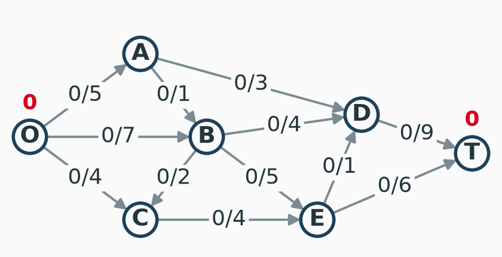

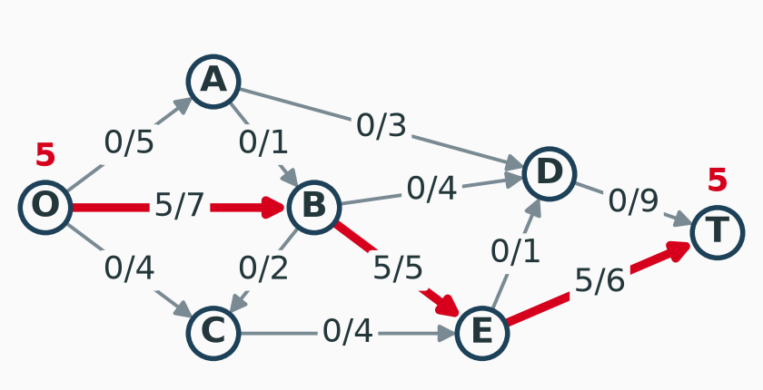

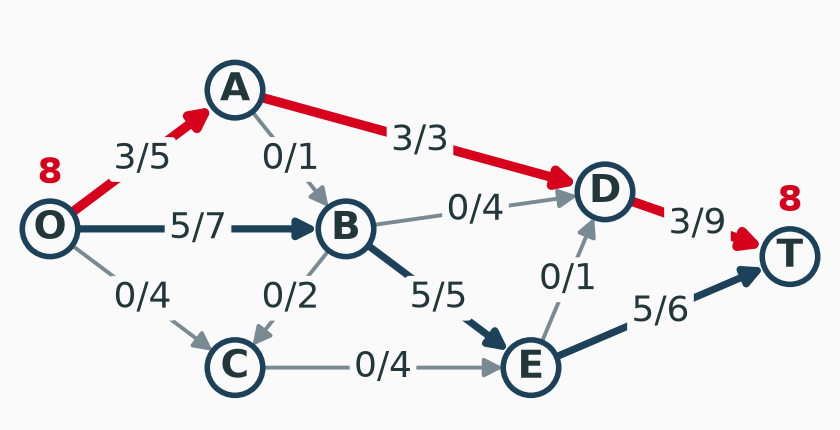

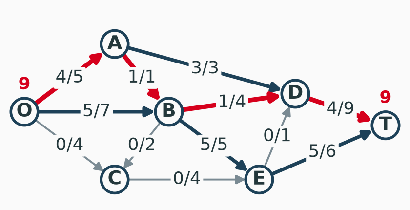

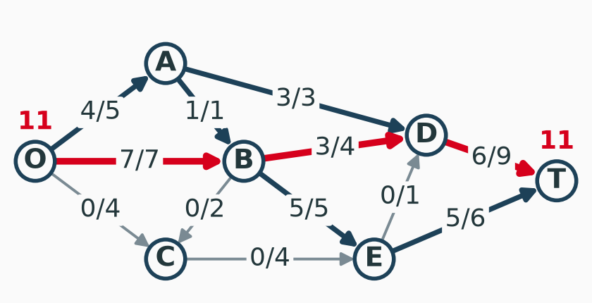

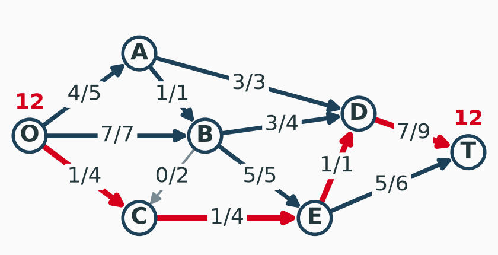

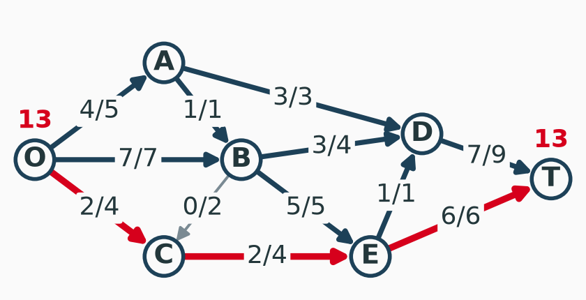

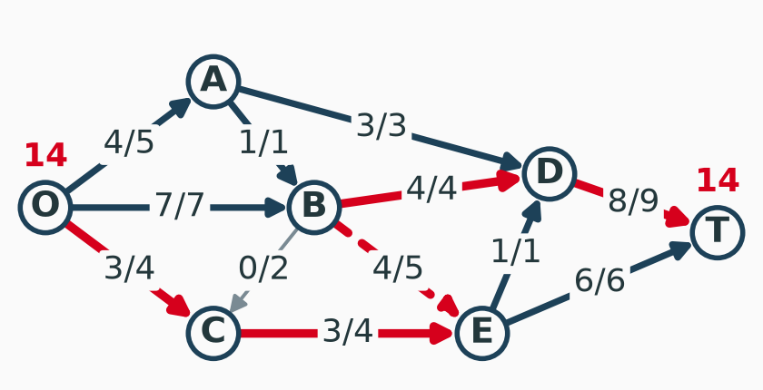

## Iteration 7 Sends Flow Backward

After 6 iterations, 13 truckloads:

- From O, only O→A (1) and O→C (2) have room; A→B and A→D are full
- From C, C→E (2); from E, both E→D and E→T are full
- E→B has residual capacity **5**: the 5 truckloads on B→E

Path O→C→E→B→D→T, ${c^* = \min\{2, 2, 5, 1, 2\} = 1}$: total 14.

**What the reverse arc does**

B→E falls from 5 to 4. In effect one truckload moves from O→B→E→T to O→B→D→T, and the freed room on E→T takes a new one, O→C→E→T.

## No Augmenting Path Is Left

Fan out from O along arcs with positive residual capacity:

- O→A (1), O→C (1), C→E (1), E→B (4), B→C (2)
- From A, B, C, E, every arc into D or T is full: A→D 3/3, B→D 4/4, E→D 1/1, E→T 6/6
- D and T cannot be reached: **14 is optimal**

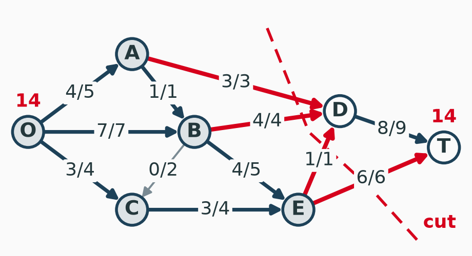

## Maximum Flow, Minimum Cut

**Cut**

Split the nodes into a set with the source and a set with the sink. The cut value is the total capacity of the arcs from the first set to the second.

- Cut ${\{O, A, B, C, E\} \mid \{D, T\}}$: A→D, B→D, E→D, E→T, value ${3 + 4 + 1 + 6 = 14}$
- Every truckload crosses every cut, so **any cut value bounds any flow**

**Max-flow min-cut theorem (Ford and Fulkerson, 1956)**

The maximum flow equals the minimum cut value. This is weak and strong duality from lecture 04: the minimum cut problem is the dual of the maximum flow LP.

## Maximum Flow as an LP

$$\begin{alignat*}{3}
\max~ & \rlap{F} \\[4pt]
\text{s.t.}~ & \textstyle\sum_j x_{Oj} - \sum_j x_{jO} & \quad & {}= F \\
& \textstyle\sum_j x_{ij} - \sum_j x_{ji} & \quad & {}= 0 && \qquad i = A, \dots, E \\
& \textstyle\sum_j x_{Tj} - \sum_j x_{jT} & \quad & {}= -F \\
& x_{ij} & \quad & {}\le u_{ij} && \qquad \text{every arc} \\
& x_{ij} & \quad & {}\ge 0 && \qquad \text{every arc}
\end{alignat*}$$

- ${u_{ij}}$: capacity of arc ${i \to j}$
- gurobipy: ${F = 14}$
- Augmenting paths solve it by hand; the simplex method solves it too

## Practice: Augmenting Paths

**Practice Problem**

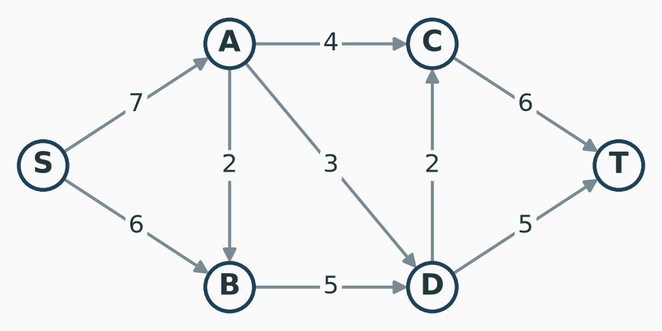

**(a)** Find the maximum flow from S to T by augmenting paths. Give the residual capacities and ${c^*}$ at each iteration.

**(b)** Find a cut whose value equals your flow. Which arcs are the bottleneck?